# Assignment 4

Dea Karam

2026-03-18

# Importing Required Packages

```r
suppressPackageStartupMessages({
  library(R.utils)
  library(AnnotationHub)
  library(ensembldb)
  library(GenomicRanges)
  library(rtracklayer)
  library(GenomeInfoDb)
  library(epiwraps)
  library(ggplot2)
  library(GenomeInfoDb)
  library(ggplot2)
  library(VennDiagram)
})
ah <- AnnotationHub()
```

# Downloading The Data

```r
## First Dataset
download.file("https://www.encodeproject.org/files/ENCFF558YNC/@@download/ENCFF558YNC.bed.gz", "mESC_H3K27me3.bed.gz")
gunzip("mESC_H3K27me3.bed.gz")

download.file("https://www.encodeproject.org/files/ENCFF350GCX/@@download/ENCFF350GCX.bed.gz", "mESC_p300.bed.gz")
gunzip("mESC_p300.bed.gz")

download.file("https://www.encodeproject.org/files/ENCFF360VIS/@@download/ENCFF360VIS.bed.gz", "mESC_H3K27ac.bed.gz")
gunzip("mESC_H3K27ac.bed.gz")


## Second Dataset
download.file("https://www.encodeproject.org/files/ENCFF887SZF/@@download/ENCFF887SZF.bed.gz", "mheart_H3K27me3.bed.gz")
gunzip("mheart_H3K27me3.bed.gz")

download.file("https://www.encodeproject.org/files/ENCFF733HUI/@@download/ENCFF733HUI.bed.gz", "mheart_H3K27ac.bed.gz")
gunzip("mheart_H3K27ac.bed.gz")

download.file("https://www.encodeproject.org/files/ENCFF318IYB/@@download/ENCFF318IYB.bed.gz", "mheart_p300.bed.gz")
gunzip("mheart_p300.bed.gz")
```

```r
# Create a peaks folder
if (!dir.exists("peaks")){
  dir.create("peaks")
  files <- list.files(pattern = "\\.bed$", full.names = TRUE)

  # Move each file into the peaks folder
  for (f in files) {
    file.rename(f, file.path("peaks", f))
  }
}
```

```r
files_mesc <- list.files("peaks", pattern = "^mESC.*\\.bed$", full.names = TRUE)
files_mheart <- list.files("peaks", pattern = "^mheart.*\\.bed$", full.names = TRUE)

names(files_mesc) <- gsub("\\.bed","",basename(files_mesc))
names(files_mheart) <- gsub("\\.bed", "", basename(files_mheart))
```

```r
peaks_mesc <- lapply(files_mesc, rtracklayer::import, format = "narrowPeak")
peaks_mheart <- lapply(files_mheart, rtracklayer::import, format = "narrowPeak")
```

```r
ah_query <- query(ah, c("Mus musculus", "EnsDb" , "GRCm38"))
ensdb_id <- rev(ah_query$ah_id)[1]
ensdb <- ah[[ensdb_id]]
```

```
## loading from cache
```

```r
ensdb
```

```
## EnsDb for Ensembl:
## |Backend: SQLite
## |Db type: EnsDb
## |Type of Gene ID: Ensembl Gene ID
## |Supporting package: ensembldb
## |Db created by: ensembldb package from Bioconductor
## |script_version: 0.3.6
## |Creation time: Sun Dec 20 12:15:16 2020
## |ensembl_version: 102
## |ensembl_host: localhost
## |Organism: Mus musculus
## |taxonomy_id: 10090
## |genome_build: GRCm38
## |DBSCHEMAVERSION: 2.1
## | No. of genes: 56305.
## | No. of transcripts: 144778.
## |Protein data available.
```

# Finding Transcription Start Sites (TSS)

```r
tss_tr <- transcripts(ensdb, columns = c("tx_id", "gene_id"))
tss <- promoters(tss_tr, upstream = 0, downstream = 1)
```

```r
seqlevelsStyle(tss) <- "UCSC"
main_chrs <- paste0("chr", c(1:19, "X", "Y"))
tss <- keepSeqlevels(tss, main_chrs, pruning.mode = "coarse")
```

# Task1:

### Finding overlaps between TSS and H3K27me3, H3K27ac or both between mESC and heart tissues.

```r
tss_overlaps <- function(tss, peaks){
  total_tss <- length(tss)
  overlaps <- overlapsAny(tss, peaks)
  overlaps_prop <- sum(overlaps)/total_tss

  return(overlaps_prop)
}
```

```r
ov_mESC_H3K27ac <- tss_overlaps(tss, peaks_mesc$mESC_H3K27ac)
ov_mESC_H3K27me3 <- tss_overlaps(tss, peaks_mesc$mESC_H3K27me3)
ov_mheart_H3K27ac <- tss_overlaps(tss, peaks_mheart$mheart_H3K27ac)
ov_mheart_H3K27me3 <- tss_overlaps(tss, peaks_mheart$mheart_H3K27me3)
both_mESC <- sum(overlapsAny(tss, peaks_mesc$mESC_H3K27ac) &
                 overlapsAny(tss, peaks_mesc$mESC_H3K27me3)) / length(tss)
both_heart <- sum(overlapsAny(tss, peaks_mheart$mheart_H3K27ac) &
                  overlapsAny(tss, peaks_mheart$mheart_H3K27me3)) / length(tss)
cat("The proportion of TSS overlapping H3K27ac in mESC is:", ov_mESC_H3K27ac, "\n")
```

```
## The proportion of TSS overlapping H3K27ac in mESC is: 0.06770852
```

```r
cat("The proportion of TSS overlapping H3K27me3 in mESC is:", ov_mESC_H3K27me3, "\n")
```

```
## The proportion of TSS overlapping H3K27me3 in mESC is: 0.01618888
```

```r
cat("The proportion of TSS overlapping H3K27ac in heart is:", ov_mheart_H3K27ac, "\n")
```

```
## The proportion of TSS overlapping H3K27ac in heart is: 0.1612014
```

```r
cat("The proportion of TSS overlapping H3K27me3 in heart is:", ov_mheart_H3K27me3, "\n")
```

```
## The proportion of TSS overlapping H3K27me3 in heart is: 0.0219616
```

```r
cat("The proportion of TSS overlapping both H3K27me3 and H3K27ac in mESC is:", both_mESC, "\n")
```

```
## The proportion of TSS overlapping both H3K27me3 and H3K27ac in mESC is: 0
```

```r
cat("The proportion of TSS overlapping both H3K27me3 and H3K27ac in heart is:", both_heart, "\n")
```

```
## The proportion of TSS overlapping both H3K27me3 and H3K27ac in heart is: 0.0006032252
```

```r
df_props <- data.frame(
  tissue = rep(c("mESC", "heart"), each = 3),
  mark   = rep(c("H3K27ac", "H3K27me3", "both"), 2),
  proportion = c(ov_mESC_H3K27ac, ov_mESC_H3K27me3, both_mESC,
                 ov_mheart_H3K27ac, ov_mheart_H3K27me3, both_heart)
)
```

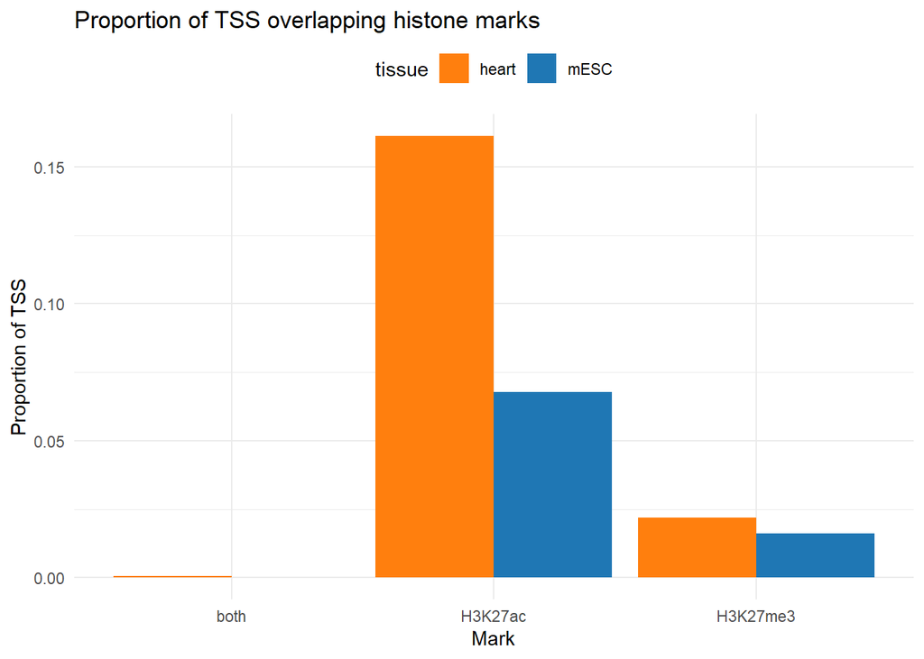

```r
ggplot(df_props, aes(x = mark, y = proportion, fill = tissue)) +
  geom_col(position = position_dodge(0.9)) +
  scale_fill_manual(values = c("mESC" = "#1f77b4", "heart" = "#ff7f0e")) +
  labs(title = "Proportion of TSS overlapping histone marks",
       x = "Mark", y = "Proportion of TSS") +
  theme_minimal() +
  theme(legend.position = "top")
```

What we can see from the bar plot is that the proportion of H3K27ac at TSS is higher in the differentiated heart tissue than in the embryonic stem cells and overall higher in both tissues compared to H3K27me3.

Most importantly, we can see that the overlap of both histone marks at TSS is near zero for both tissues. This closely follows what we already know from biology that H3K27ac is a marker of active TSS while H3K27me3 is a marker of repressed elements and that both are mutually exclusive. A single Lysine (K) cannot be both trimethylated and acetylated.

# Task2

### Finding the relationship between the 3 signals (p300, H3K27ac, and H3K27me3) in both tissues

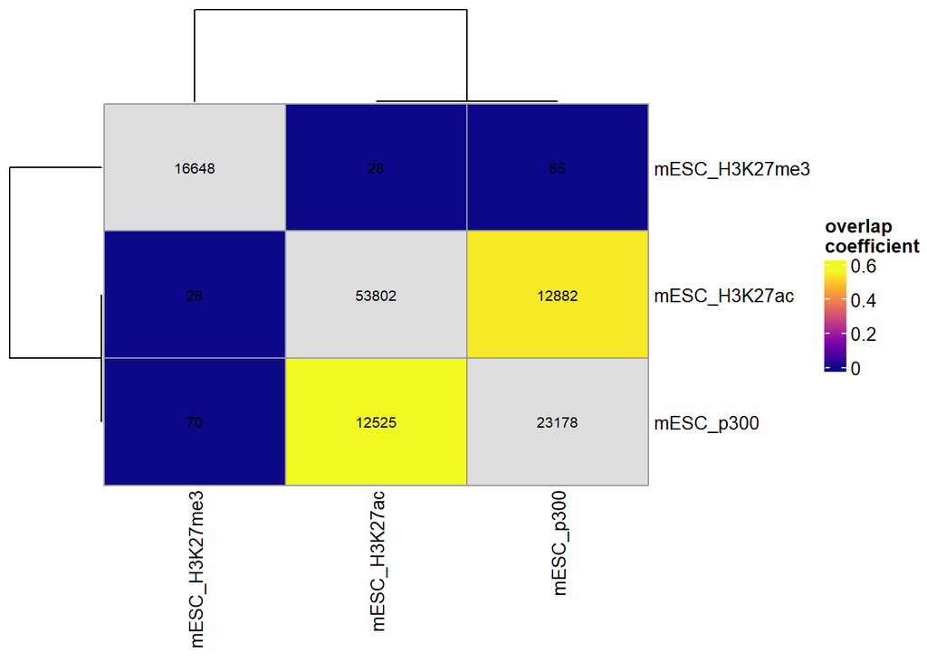

```r
regionOverlaps(peaks_mesc)
```

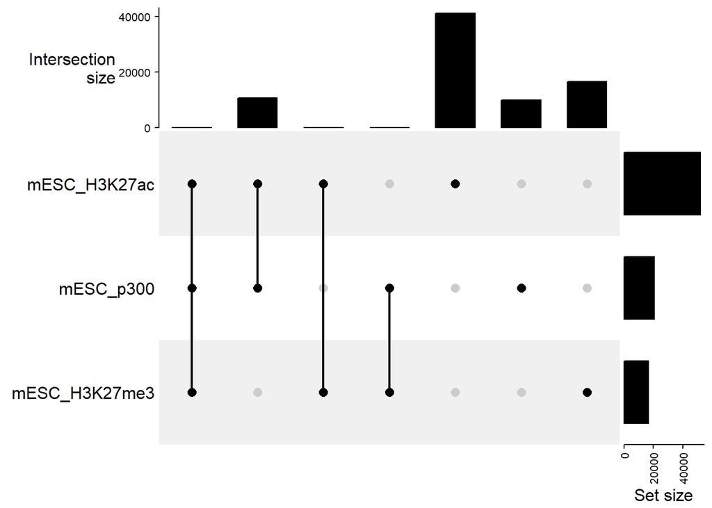

```r
tmp <- regionsToUpset(peaks_mesc, nsets=length(peaks_mesc))
UpSet(make_comb_mat(tmp))
```

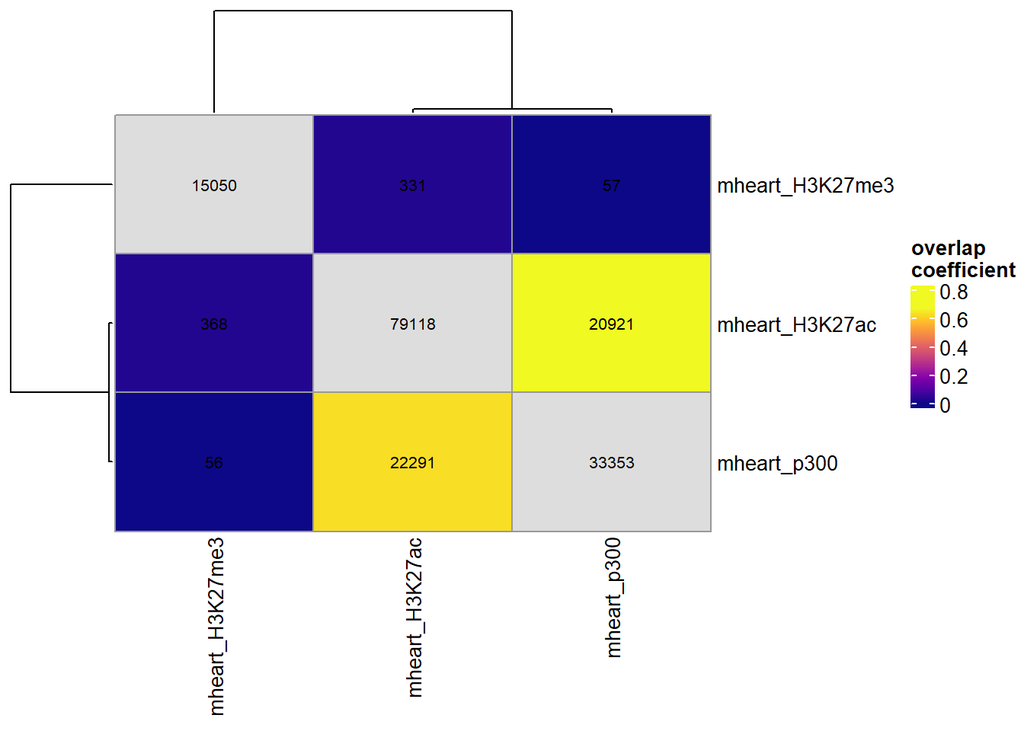

```r
regionOverlaps(peaks_mheart)
```

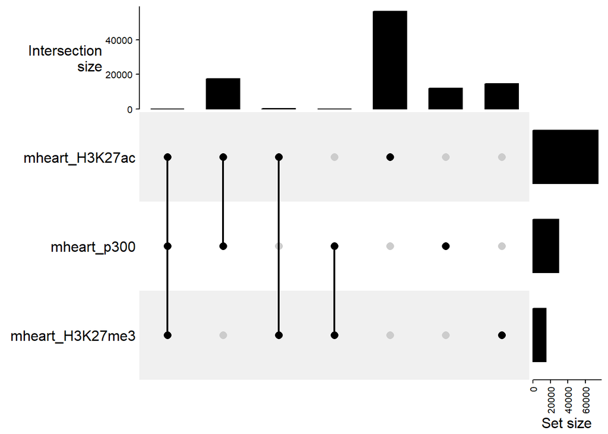

```r
tmp <- regionsToUpset(peaks_mheart, nsets=length(peaks_heart))
UpSet(make_comb_mat(tmp))
```

# Task3

## Finding the relationship between regulatory elements active in mESC and in the heart

### p300

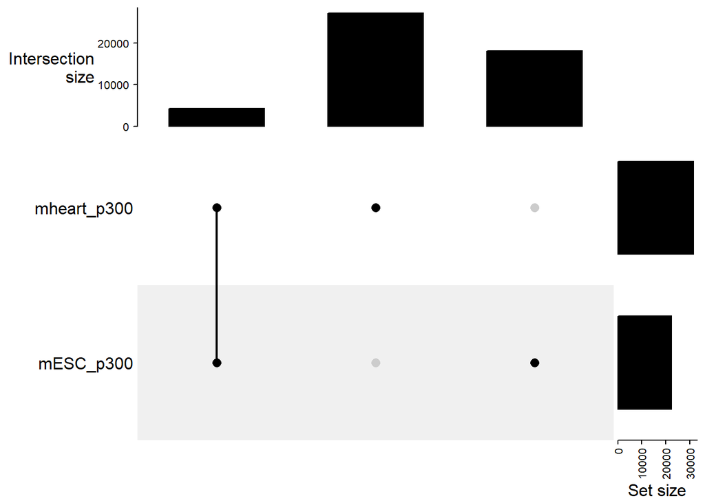

```r
p300_list <- list(mESC_p300 = peaks_mesc$mESC_p300, mheart_p300 = peaks_mheart$mheart_p300)
tmp <- regionsToUpset(p300_list, nsets=length(p300_list))
UpSet(make_comb_mat(tmp))
```

### H3K27ac

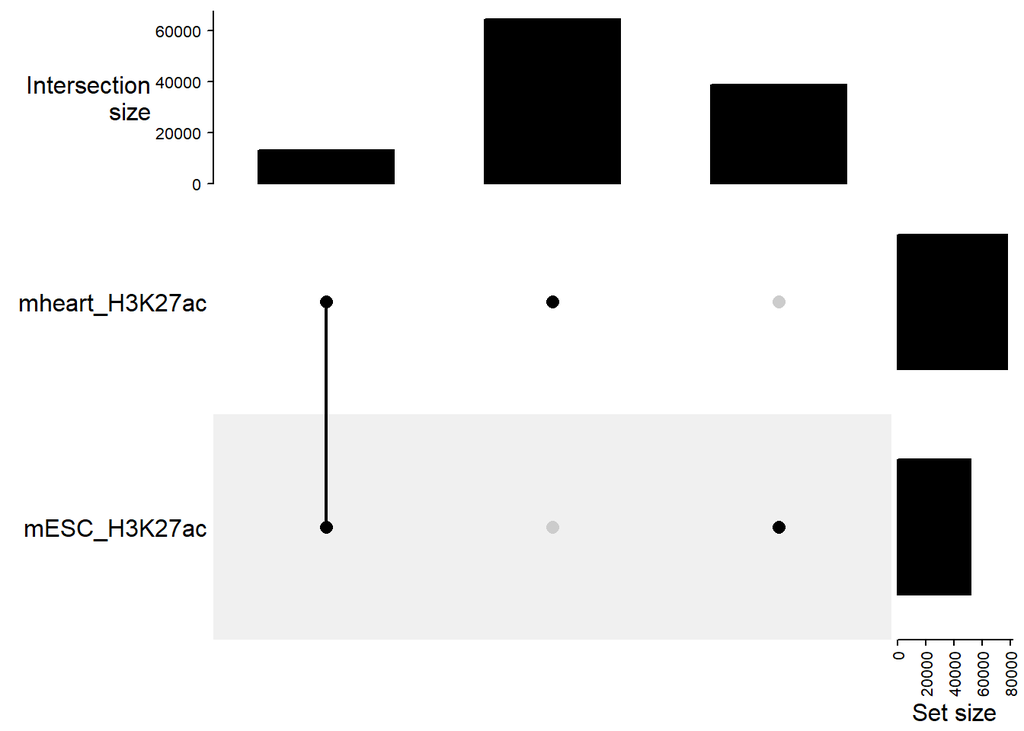

```r
H3K27ac_list <- list(mESC_H3K27ac = peaks_mesc$mESC_H3K27ac, mheart_H3K27ac = peaks_mheart$mheart_H3K27ac)
tmp <- regionsToUpset(H3K27ac_list, nsets=length(H3K27ac_list))
UpSet(make_comb_mat(tmp))
```

### H3K27me3

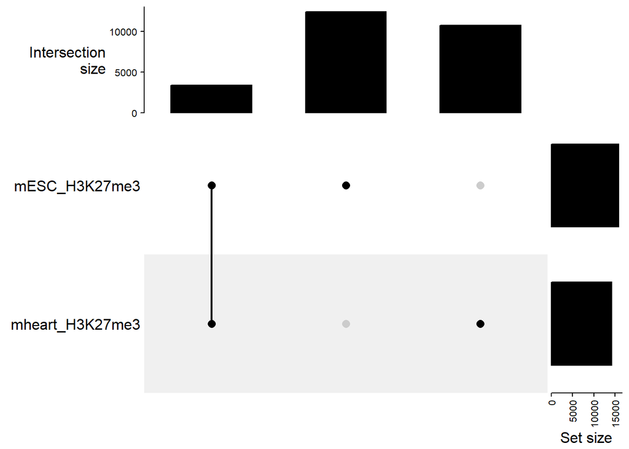

```r
H3K27me3_list <- list(mESC_H3K27me3 = peaks_mesc$mESC_H3K27me3, mheart_H3K27me3 = peaks_mheart$mheart_H3K27me3)
tmp <- regionsToUpset(H3K27me3_list, nsets=length(H3K27me3_list))
UpSet(make_comb_mat(tmp))
```

The UpSet plots show that regulatory elements are largely tissue-specific, with many peaks unique to either mESC or the differentiated heart tissue, and a smaller subset shared between both. This indicates that differentiation involves extensive changes in the regulatory landscape of a cell, where some stem cell specific elements are lost and new tissue specific elements are activated. However, the presence of a shared subset suggests that some core regulatory elements are still conserved across cell types. These elements are likely associated with fundamental cellular functions.

## Remark:

I could not get the warning signs to go away despite my best efforts. I am unsure why the issue might be arising.